# Outcrossing Populations

[Statistical Genetics Lab](http://statgen.esalq.usp.br) Department of Genetics Luiz de Queiroz College of Agriculture University of São Paulo

2021-11-06

The following example is intended to show the usage of `OneMap` functions for linkage mapping in outcrossing (non-inbred) populations. With basic knowledge of R syntax, one should have no problems using it. If you are not familiar with R, we recommend reading the vignette [Introduction to R](https://statgen-esalq.github.io/tutorials/onemap/Introduction_R.html).

Hopefully, these examples will be clear enough to help any user to understand its functionality and start using it. You do not need to be an expert in R to build your linkage map, but some concepts are necessary and will help you through the process.

There is a GitHub `OneMap` version which is continuously improved, we strongly recommend all users to try [this version](https://github.com/augusto-garcia/onemap). On `augusto-garcia/onemap` GitHub page you can find instructions to install the package from GitHub and also more fancy tutorials.

# Creating the data file

This step may be quite difficult because the data file is not very simple, and some errors can occur while reading it. The input file format is similar to that used by MAPMAKER/EXP (Lander et al., 1987), so experienced users of genetic analysis software should be already familiar with this scenario.

The input file is a text file, where the first line indicates the cross-type, and the second line provides information about the number of individuals, the number of markers, the presence of physical marker locations, and the presence of phenotypic data. The third line contains the sample IDs. Then, the genotype information is included separately for each marker. The character `*` indicates the beginning of information input for a new marker, followed by the marker name. Next, there is a code indicating the marker type, according to Wu’s et al. (2002a) notation. It is recommended to check Wu’s et al. (2002a) paper before using `OneMap`.

Marker types must be one of the following: `A.1`, `A.2`, `A.3`, `A.4`, `B1.5`, `B2.6`, `B3.7`, `C.8`, `D1.9`, `D1.10`, `D1.11`, `D1.12`, `D1.13`, `D2.14`, `D2.15`, `D2.16`, `D2.17` or `D2.18`, each one corresponding to a row of the following table:

|  |  |  | Parent |  | Offspring |  |
| --- | --- | --- | --- | --- | --- | --- |
|  |  | Crosstype | Cross | Observed bands | Observed bands | Segregation |
| $A$ |  | 1 | $ab \times cd$ | $ab \times cd$ | $ac, ad, bc, bd$ | $1:1:1:1$ |
|  |  | 2 | $ab \times ac$ | $ab \times ac$ | $a, ac, ba, bc$ | $1:1:1:1$ |
|  |  | 3 | $ab \times co$ | $ab \times c$ | $ac, a, bc,b$ | $1:1:1:1$ |
|  |  | 4 | $ao \times bo$ | $a \times b$ | $ab, a, b, o$ | $1:1:1:1$ |
| $B$ | $B_1$ | 5 | $ab \times ao$ | $ab \times a$ | $ab, 2a,b$ | $1:2:1$ |
|  | $B_2$ | 6 | $ao \times ab$ | $a \times ab$ | $ab,2a,b$ | $1:2:1$ |
|  | $B_3$ | 7 | $ab \times ab$ | $ab \times ab$ | $a, 2ab,b$ | $1:2:1$ |
| $C$ |  | 8 | $ao \times ao$ | $a \times a$ | $3a, o$ | $3:1$ |
| $D$ | $D_1$ | 9 | $ab \times cc$ | $ab \times c$ | $ac, bc$ | $1:1$ |
|  |  | 10 | $ab \times aa$ | $ab \times a$ | $a, ab$ | $1:1$ |
|  |  | 11 | $ab \times oo$ | $ab \times o$ | $a, b$ | $1:1$ |
|  |  | 12 | $bo \times aa$ | $b \times a$ | $ab, a$ | $1:1$ |
|  |  | 13 | $ao \times oo$ | $a \times o$ | $a, o$ | $1:1$ |
|  | $D_2$ | 14 | $cc \times ab$ | $c \times ab$ | $ac, bc$ | $1:1$ |
|  |  | 15 | $aa \times ab$ | $a \times ab$ | $a, ab$ | $1:1$ |
|  |  | 16 | $oo \times ab$ | $o \times ab$ | $a, b$ | $1:1$ |
|  |  | 17 | $aa \times bo$ | $a \times b$ | $ab, a$ | $1:1$ |
|  |  | 18 | $oo \times ao$ | $o \times a$ | $a, o$ | $1:1$ |

Letters `A`, `B`, `C` and `D` indicate the segregation type (*i.e.*, `1:1:1:1`, `1:2:1`, `3:1` or `1:1`, respectively), while the number after the dot (*e.g.*, `A.1`) indicates the observed bands in the offspring. The paper cited above gives details with respect to marker types; we will not discuss them here, but it is easy to see that each marker is classified based on the band patterns of parents and progeny.

Finally, after each marker name, comes the genotype data for the segregating population. The coding for marker genotypes used by `OneMap` is also the same one proposed by Wu et al. (2002a), and the possible values vary according to the specific marker type. Missing data are indicated with the character `-` (minus sign), and an empty space separates the information for each individual. Phenotype information, if present, follows genotypic data with a similar structure. Details are found with the help of function `read_onemap`.

Here is an example of such a file for 10 individuals and 5 markers (the three zeros in the second line indicate that there is no chromosome information, physical position information, or phenotypic data, respectively). It is very similar to a MAPMAKER/EXP file, but has additional information about the cross-type.

```
data type outcross
10 5 0 0 0
I1 I2 I3 I4 I5 I6 I7 I8 I9 I10
*M1 B3.7 ab ab - ab b ab ab - ab b
*M2 D2.18 o - a a - o a - o o
*M3 D1.13 o a a o o - a o a o
*M4 A.4 ab b - ab a b ab b - a
*M5 D2.18 a a o - o o a o o o
```

Notice that once the marker type is identified, no variations of symbols presented on the table for the **observed bands** are allowed. For example, for `A.1`, only `ac`, `ad`, `bc`, and `bd` genotypes are expected (plus missing values). **We notice in FAQs that this is a common mistake made by users, so please be careful**.

The input file must be saved in text format, with extensions like `.raw`. It is a good idea to open the text file called `onemap_example_out.raw` (available with `OneMap` and saved in the directory you installed it) to see how this file should be. You can see where `OneMap` is installed using the command:

```r
system.file(package = "onemap")
```

In the session `Importing data from VCF file` below, you will see how to import VCF files as `OneMap` objects.

# Importing data

Once the input file is created, the data can be loaded and saved into an R `onemap` object. The function used to import data is named `read_onemap`. Its usage is quite simple:

```r
onemap_example_out <- read_onemap(dir = "C:/workingdirectory", inputfile = "onemap_example_out.raw")
```

The first argument is the directory where the input file is located, so modify it accordingly. The second one is the data file name. In this example, an object named `onemap_example_out` was created. If you leave the argument `dir` blank, the file will be loaded from your `working directory`.

You can change the working directory in R using function `setwd()` or in the toolbar clicking `File -> Change dir`. If you set your working directory to the one containing the input file, you can just type:

```r
onemap_example_out <- read_onemap(inputfile = "onemap_example_out.raw")
```

If no error has occurred, a message will display some basic information about the data, such as number of individuals and number of markers:

```
#>  Working...
#>
#>  --Read the following data:
#>  Type of cross:           outcross
#>  Number of individuals:   100
#>  Number of markers:       30
#>  Chromosome information:  no
#>  Position information:    no
#>  Number of traits:        3
#>  Missing trait values:
#>   Pheno1: 0
#>   Pheno2: 3
#>   Pheno3: 0
```

Because this particular dataset is distributed along with the package, as an alternative you can load it by typing:

```r
data("onemap_example_out")
```

Loading the data creates an object of class `onemap`, which will further be used in the analysis. R command `print` recognizes objects of this class. Thus, if you type:

```r
onemap_example_out
```

you will see some information about the object:

```
#>   This is an object of class 'onemap'
#>     Type of cross:      outcross
#>     No. individuals:    100
#>     No. markers:        30
#>     CHROM information:  no
#>     POS information:    no
#>     Percent genotyped:  100
#>
#>     Segregation types:
#>                 A.1 -->  3
#>                 A.2 -->  1
#>                 A.4 -->  4
#>                B1.5 -->  1
#>                B2.6 -->  2
#>                B3.7 -->  5
#>                 C.8 -->  2
#>               D1.10 -->  2
#>               D1.12 -->  1
#>               D1.13 -->  2
#>               D2.15 -->  1
#>               D2.16 -->  2
#>               D2.17 -->  2
#>               D2.18 -->  2
#>
#>     No. traits:         3
#>     Missing trait values:
#>   Pheno1: 0
#>   Pheno2: 3
#>   Pheno3: 0
```

Also, you can use the `plot.onemap` function to see graphically markers genotypes:

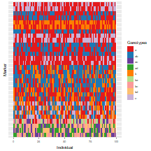

```r
plot(onemap_example_out)
```

Changing the argument `all` to `FALSE`, the markers will be separated by their type. In this case, you can note that the graphic cell size will adapt to the number of markers of the same type. In other words, the higher is the number of markers with the same type, the lower is the cell for this type.

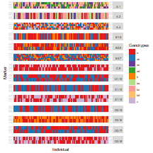

```r
plot(onemap_example_out, all = FALSE)
```

This function can take quite some time, depending on the number of markers involved. More information about this plot function can be found using `?plot.onemap`.

## Importing data from VCF file

You can import information from `VCF` to `OneMap` using `onemap_read_vcfR` function.

With the `onemap_read_vcfR` you can convert the object from `vcfR` package directly to `onemap`. The `onemap_read_vcfR` function keeps chromosome and position information for each marker in the onemap object generated.

We will use the example file `vcf_example_out.vcf.gz` to show how it works, which contains markers from the same population of `onemap_example_out.raw`.

Here we use the the `vcfR` package internally to help this conversion. The `vcfR` authors mentioned in their [tutorials](https://knausb.github.io/vcfR_documentation/index.html) that RAM memory use is an important consideration when using the package. Depending of your dataset, the object created can be huge and occupy a lot of memory.

You can use `onemap_read_vcfR` function to convert the VCF file to `onemap` object. The parameters used are the `vcf` with the VCF file path, the identification of each parent (here, you must define only one sample for each parent) and the cross type.

```r
vcf_example_out <- onemap_read_vcfR(vcf = system.file("extdata/vcf_example_out.vcf.gz", package = "onemap"),
                                    parent1 = "P1",
                                    parent2 = "P2",
                                    cross = "outcross")
```

Depending on your dataset, this function can take some time to run.

Note that the conversion filter out markers which are not informative for the informed cross type. For example, in outcrossing species, markers that have both parents homozygous (aa x bb) do not inform recombinations and are removed of the data set. Only markers types contained the table at Creating the data file are kept in the onemap object. Function `onemap_read_vcfR` print at the screen the reason why markers were filtered.

You can also have more missing data in the returned object compared with the VCF because the `onemap_read_vcfR` replace by missing data the genotypes that are not expected for that marker type. For example, for a marker type D1.10 (`ab` x `aa`), we only expect `aa` and `ab` genotypes, if there are `bb` genotypes they will be replaced by missing data. You can see the percentage of missing data at the resulted onemap object with:

```r
vcf_example_out
```

```
#>   This is an object of class 'onemap'
#>     Type of cross:      outcross
#>     No. individuals:    92
#>     No. markers:        24
#>     CHROM information:  yes
#>     POS information:    yes
#>     Percent genotyped:  99
#>
#>     Segregation types:
#>                B3.7 -->  18
#>               D1.10 -->  6
#>
#>     No. traits:         0
```

**NOTE**:From version 2.0.6 to 2.1.1005, `OneMap` had the `vcf2raw` function to convert `vcf` to `.raw`. Now, this function is defunct, but it can be replaced by a combination of `onemap_read_vcfR` and `write_onemap_raw` functions. See Exporting .raw file from onemap object session to further information about `write_onemap_raw`.

# Filter onemap object by missing data

If your onemap object has too many missing genotypes you can face problems during the analysis. Check the percentage of missing genotypes in our data set printing the onemap object:

```r
vcf_example_out
```

```
#>   This is an object of class 'onemap'
#>     Type of cross:      outcross
#>     No. individuals:    92
#>     No. markers:        24
#>     CHROM information:  yes
#>     POS information:    yes
#>     Percent genotyped:  99
#>
#>     Segregation types:
#>                B3.7 -->  18
#>               D1.10 -->  6
#>
#>     No. traits:         0
```

Our example has 1% of missing genotypes (99% are genotyped). If you want to filter markers according to their percentage of missing data, you can use the function `filter_missing`:

```r
vcf_filtered <- filter_missing(vcf_example_out, threshold = 0.25)
```

```
#> Number of markers removed from the onemap object:  0
```

Any of our markers were filtered, because, in this example, we do not have much missing data.

# Graphical view of genotypes and allele depths (new!)

Function `create_depth_profile` generates dispersion graphics with x and y-axis representing, respectively, the reference and alternative allele depths. The function is only available for biallelic markers in VCF files with allele counts information. Each dot represents a genotype for `mks` markers and `inds` individuals. If both arguments receive `NULL`, all markers and individuals are considered. Dots are colored according to the genotypes present in the onemap object (`GTfrom = onemap`) or VCF file (`GTfrom = vcf`). A rds file is generated with the data in the graphic (`rds.file`). The `alpha` argument controls the transparency of the color of each dot. Control this parameter is a good idea when having a large number of markers and individuals. The `x_lim` and `y_lim` control the axis scale limits; by default, it uses the maximum value of the counts.

Here is an example for the `vcf_example_out` dataset.

```r
# For outcrossing population
create_depths_profile(onemap.obj = vcf_example_out,
                      vcf = system.file("extdata/vcf_example_out.vcf.gz", package = "onemap"),
                      parent1 = "P1",
                      parent2 = "P2",
                      vcf.par = "AD",
                      recovering = FALSE,
                      mks = NULL,
                      inds = NULL,
                      GTfrom = "vcf",
                      alpha = 0.1,
                      rds.file = "depths_out.rds")
```

[output not shown]

Because the genotypes are from VCF file, the legend points the VCF codification? `./.` represent missing data; `0/0` homozygotes for reference alleles; `0/1` heterozygotes; `1/1` homozygotes for alternative alleles. You can also have phased genotypes represented which have pipe `|` instead of bar `/`.

# Combining `OneMap` datasets

If you have more than one dataset of markers, all from the same mapping population, you can use the function `combine_onemap` to merge them into only one `onemap` object.

In our example, we have two datasets:

- first: `onemap_example_out` with 30 markers and 100 individuals
- second: `vcf_example_out` with 24 biallelic markers and 92 individuals.

The `combine_function` recognizes the correspondent individuals by the ID, thus, it is important to define the same IDs to respective individuals in both `raw` files. Compared with the first file, the second file does not have markers information for 8 individuals. The `combine_onemap` will complete this information with NA.

```r
comb_example <- combine_onemap(onemap_example_out, vcf_example_out)
comb_example
```

```
#>   This is an object of class 'onemap'
#>     Type of cross:      outcross
#>     No. individuals:    100
#>     No. markers:        54
#>     CHROM information:  yes
#>     POS information:    yes
#>     Percent genotyped:  96
#>
#>     Segregation types:
#>                 A.1 -->  3
#>                 A.2 -->  1
#>                 A.4 -->  4
#>                B1.5 -->  1
#>                B2.6 -->  2
#>                B3.7 -->  23
#>                 C.8 -->  2
#>               D1.10 -->  8
#>               D1.12 -->  1
#>               D1.13 -->  2
#>               D2.15 -->  1
#>               D2.16 -->  2
#>               D2.17 -->  2
#>               D2.18 -->  2
#>
#>     No. traits:         3
#>     Missing trait values:
#>   Pheno1: 0
#>   Pheno2: 3
#>   Pheno3: 0
```

The function arguments are the names of the `onemap` objects you want to combine.

Plotting markers genotypes from the outputted `onemap` object, we can see that there are more missing data `-` (black vertical lines) for some individuals because they were missing in the second file.

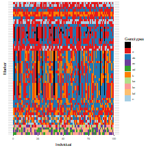

```r
plot(comb_example)
```

# Find redundant markers

It is possible that there are redundant markers in your dataset, especially when dealing with too many markers. Redundant markers have the same genotypic information that other markers because they didn’t happen recombination events between each other. They will not increase information on the map but will increase computational effort during the map building. Therefore, it is a good practice to remove them to build the map and, once the map is already built, they can be added again.

First, we use the function `find_bins` to group the markers into bins according to their genotypic information. In other words, markers with the same genotypic information will be in the same bin.

```r
bins <- find_bins(comb_example, exact = FALSE)
bins
```

```
#> This is an object of class 'onemap_bin'
#>     No. individuals:                         100
#>     No. markers in original dataset:         54
#>     No. of bins found:                       52
#>     Average of markers per bin:              1.038462
#>     Type of search performed:                non exact
```

The first argument is the `onemap` object and the `exact` argument specifies if only markers with the same information will be at the same bin. Using `FALSE` at this second argument, missing data will not be considered, and the marker with the lowest amount of missing data will be the representative marker on the bin.

Our example dataset has only two redundant markers. We can create a new `onemap` object without them, using the `create_data_bins` function. This function keeps only the most representative marker of each bin from the `bins` object.

```r
bins_example <- create_data_bins(comb_example, bins)
bins_example
```

```
#>   This is an object of class 'onemap'
#>     Type of cross:      outcross
#>     No. individuals:    100
#>     No. markers:        52
#>     CHROM information:  yes
#>     POS information:    yes
#>     Percent genotyped:  96
#>
#>     Segregation types:
#>                 A.1 -->  3
#>                 A.2 -->  1
#>                 A.4 -->  4
#>                B1.5 -->  1
#>                B2.6 -->  2
#>                B3.7 -->  22
#>                 C.8 -->  2
#>               D1.10 -->  7
#>               D1.12 -->  1
#>               D1.13 -->  2
#>               D2.15 -->  1
#>               D2.16 -->  2
#>               D2.17 -->  2
#>               D2.18 -->  2
#>
#>     No. traits:         3
#>     Missing trait values:
#>   Pheno1: 0
#>   Pheno2: 3
#>   Pheno3: 0
```

The arguments for the `create_data_bins` function are the `onemap` object and the object created by the `find_bins` function.

# Exporting .raw file from onemap object

The functions `onemap_read_vcfR` generates new onemap objects without use a input `.raw` file. Also, the functions `combine_onemap` and `create_data_bins` manipulate the information of the original `.raw` file and creates a new dataset. In both cases, you do not have an input file `.raw` that contains the same information as the analyzed data. If you want to create a new input file with the dataset you are working on after using these functions, you can use the function `write_onemap_raw`.

```r
write_onemap_raw(bins_example, file.name = "new_dataset.raw")
```

The file `new_dataset.raw` will be generated in your working directory. In our example, it contains only non-redundant markers from `onemap_example_out` and `vcf_example_out` datasets.

# Testing segregation pattern

For the map building process, it is also important to know which markers have deviations in the expected segregation pattern. It can be a good practice to remove them from the map building process, because they can adversely affect the map building, and, once the map is built, they can be inserted.

The function `test_segregation_of_a_marker` performs a chi-square test according to Mendelian segregation to check if a specific marker is following the expected segregation pattern.

```r
test_segregation_of_a_marker(bins_example, 4)
```

```
#> $Hypothesis
#> [1] "1:1:1:1"
#>
#> $qui.quad
#> X-squared
#>      2.64
#>
#> $p.val
#> [1] 0.4505201
#>
#> $perc.genot
#> [1] 100
```

The arguments are the `onemap` object and the number of the marker you want to test.

You can also test all the markers in your `onemap` object using the `test_segregation` function. The results can be viewed by printing the output object of class `onemap_segreg_test`.

```r
segreg_test <- test_segregation(bins_example)
print(segreg_test)
```

```
#>    Marker      H0  Chi-square      p-value % genot.
#> 1      M1   1:2:1  1.76000000 4.147829e-01      100
#> 2      M2     1:1  0.04000000 8.414806e-01      100
#> 3      M3     1:1  0.36000000 5.485062e-01      100
#> 4      M4 1:1:1:1  2.64000000 4.505201e-01      100
#> 5      M5     1:1  1.96000000 1.615133e-01      100
#> 6      M6   1:2:1  1.52000000 4.676664e-01      100
#> 7      M7     1:1  0.16000000 6.891565e-01      100
#> 8      M8   1:2:1  0.86000000 6.505091e-01      100
#> 9      M9     1:1  0.04000000 8.414806e-01      100
#> 10    M10     1:1  0.36000000 5.485062e-01      100
#> 11    M11     1:1  0.16000000 6.891565e-01      100
#> 12    M12 1:1:1:1  6.48000000 9.045460e-02      100
#> 13    M13     3:1  0.00000000 1.000000e+00      100
#> 14    M14 1:1:1:1  0.40000000 9.402425e-01      100
```

[output cut: 38 more lines]

The only argument of the function is a `onemap` object.

Once we have the `onemap_segreg_test`object, the function `select_segreg` can be used to show only the markers considered with/without segregation distortion. By default, it uses as a threshold for the test a global $\alpha=0.05$, corrected for multiple tests with Bonferroni correction.

```r
select_segreg(segreg_test, distorted = TRUE) #to show the markers names with segregation distortion
```

```
#> [1] "M17" "M19" "M25"
```

```r
select_segreg(segreg_test, distorted = FALSE) #to show the markers names without segregation distortion
```

```
#>  [1] "M1"    "M2"    "M3"    "M4"    "M5"    "M6"    "M7"    "M8"    "M9"
#> [10] "M10"   "M11"   "M12"   "M13"   "M14"   "M15"   "M16"   "M18"   "M20"
#> [19] "M21"   "M22"   "M23"   "M24"   "M26"   "M27"   "M28"   "M29"   "M30"
#> [28] "SNP1"  "SNP2"  "SNP3"  "SNP5"  "SNP6"  "SNP7"  "SNP8"  "SNP9"  "SNP10"
#> [37] "SNP11" "SNP12" "SNP13" "SNP14" "SNP16" "SNP17" "SNP18" "SNP20" "SNP21"
#> [46] "SNP22" "SNP23" "SNP24" "SNP25"
```

It is not recommended, but you can define a different threshold value by changing the `threshold` argument of the function `select_segreg`.

For the next steps, it will be useful to know the numbers of each marker with segregation distortion, so then you can keep those out of your map building analysis. These numbers refer to the lines where markers are located on the data file.

To access the corresponding number for these markers you can change the `numbers` argument:

```r
dist <- select_segreg(segreg_test, distorted = TRUE, numbers = TRUE) #to show the markers numbers with segregation distortion
dist
```

```
#> [1] 17 19 25
```

```r
no_dist <- select_segreg(segreg_test, distorted = FALSE, numbers = TRUE) #to show the markers numbers without segregation distortion
no_dist
```

```
#>  [1]  1  2  3  4  5  6  7  8  9 10 11 12 13 14 15 16 18 20 21 22 23 24 26 27 28
#> [26] 29 30 31 32 33 34 35 36 37 38 39 40 41 42 43 44 45 46 47 48 49 50 51 52
```

You can also see the results graphically by:

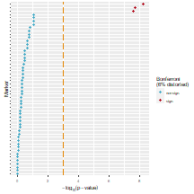

```r
plot(segreg_test)
```

# Strategies for this tutorial example

Now, we start the map building analysis. In this example, we follow two different strategies:

- Using only recombinations information.
- Using the recombinations and also the reference genome information, once our example has `CHROM` and `POS` information for some of the markers.

First, we will apply the strategy using only recombinations information. In the second part of this tutorial, we show a way to use also reference genome information. At the end of our analysis, we will be able to compare these two strategies by drawing the resulted genetic maps.

# Using only recombinations information

## Estimating two-point recombination fractions

The first step is estimating the recombination fraction between all pairs of markers, using two-point tests.

```r
twopts <- rf_2pts(bins_example)
```

Although two-point tests were implemented in C language, which is usually much faster than R, this step can take quite some time, depending on the number of markers involved and their segregation type, because all combinations will be estimated and tested. Besides, the results use a a lot of memory and a rather powerful computer is needed.

When the two-point analysis is finished, an object of class `rf_2pts` is created. Typing

```r
twopts
```

will show a message with the criteria used in the analysis and some other information:

```
#>   This is an object of class 'rf_2pts'
#>
#>   Criteria: LOD = 3 , Maximum recombination fraction = 0.5
#>
#>   This object is too complex to print
#>   Type 'print(object, c(mrk1=marker, mrk2=marker))' to see
#>     the analysis for two markers
#>     mrk1 and mrk2 can be the names or numbers of both markers
```

If you want to see the results for given markers, say `M1` and `M3`, the command is:

```r
print(twopts, c("M1", "M3"))
```

```
#>   Results of the 2-point analysis for markers: M1 and M3
#>   Criteria: LOD =  3 , Maximum recombination fraction =  0.5
#>
#>           rf      LOD
#> CC 0.2954514 1.646878
#> CR 0.2954514 1.646878
#> RC 0.7045486 1.646878
#> RR 0.7045486 1.646878
```

Each line corresponds to a possible linkage phase. `CC` denotes the coupling phase in both parents, `CR` and `RC` denote coupling phase in parent 1 and 2, respectively, and repulsion in the other, and `RR` denotes the repulsion phase in both parents. Value `rf` is the maximum likelihood estimate of the recombination fraction, with its corresponding LOD Score.

## Assigning markers to linkage groups

Once the recombination fractions and linkage phases for all pairs of markers have been estimated and tested, markers can be assigned to linkage groups. To do this, first, use the function `make_seq` to create a sequence with the markers you want to assign.

The function `make_seq` is used to create sequences from objects of several kinds, as will be seen along with this tutorial.

Here, the object is of class `rf_2pts` and the second argument specifies which markers one wants to use. If one wants to use only a subset of markers, say `M1` and `M2`, the option will be a vector with the corresponding numbers of the markers, as `c(1,2)`, you can also use a string `"all"` to specify that you want to analyze all markers. In our example, we will use the vector with the numbers of the markers with no segregation distortion.

```r
mark_no_dist <- make_seq(twopts, c(no_dist))
```

Because the identification of the markers can be cumbersome, one should use the function `marker type` to see their numbers, names, and types:

```r
marker_type(mark_no_dist)
```

```
#>  [1] "  Marker 1 ( M1 ) is of type B3.7 \n"
#>  [2] "  Marker 2 ( M2 ) is of type D2.18 \n"
#>  [3] "  Marker 3 ( M3 ) is of type D1.13 \n"
#>  [4] "  Marker 4 ( M4 ) is of type A.4 \n"
#>  [5] "  Marker 5 ( M5 ) is of type D2.18 \n"
#>  [6] "  Marker 6 ( M6 ) is of type B3.7 \n"
#>  [7] "  Marker 7 ( M7 ) is of type D2.15 \n"
#>  [8] "  Marker 8 ( M8 ) is of type B3.7 \n"
#>  [9] "  Marker 9 ( M9 ) is of type D1.10 \n"
#> [10] "  Marker 10 ( M10 ) is of type D2.17 \n"
#> [11] "  Marker 11 ( M11 ) is of type D2.16 \n"
#> [12] "  Marker 12 ( M12 ) is of type A.2 \n"
#> [13] "  Marker 13 ( M13 ) is of type C.8 \n"
#> [14] "  Marker 14 ( M14 ) is of type A.4 \n"
#> [15] "  Marker 15 ( M15 ) is of type A.4 \n"
```

[output cut: 34 more lines]

OneMap has two different functions for grouping markers. The `group` function:

```r
LGs <- group(mark_no_dist)
```

```
#>    Selecting markers:
#>    group    1
#>     ........................
#>    group    2
#>     ................
#>    group    3
#>     ......
```

For this function, optional arguments are `LOD` and `max.rf`, which define thresholds to be used when assigning markers to linkage groups. If none is provided (default), it uses as default values of LOD Score `3` and maximum recombination fraction `0.50`.

Also, you can use the function `suggest_lod` to calculate a suggested LOD score considering that multiple tests are being performed.

```r
LOD_sug <- suggest_lod(mark_no_dist)
LOD_sug
```

```
#> [1] 3.639312
```

And apply this suggested value to the two-point tests:

```r
LGs <- group(mark_no_dist, LOD=LOD_sug)
```

```
#>    Selecting markers:
#>    group    1
#>     ........................
#>    group    2
#>     ................
#>    group    3
#>     ......
```

The previous command generates an object of class `group` and the command `print` for such object has two options. If you type:

```r
LGs
```

you will get detailed information about the groups, that is, all linkage groups will be printed, displaying the names of markers in each one of them.

```
#>   This is an object of class 'group'
#>   It was generated from the object "mark_no_dist"
#>
#>   Criteria used to assign markers to groups:
#>     LOD = 3.639312 , Maximum recombination fraction = 0.5
#>
#>   No. markers:            49
#>   No. groups:             3
#>   No. linked markers:     49
#>   No. unlinked markers:   0
#>
#>   Printing groups:
#>   Group 1 : 25 markers
#>     M1 M2 M3 M5 M6 M10 M11 M12 M14 M15 M26 M28 M30 SNP1 SNP2 SNP3 SNP5 SNP6 SNP7 SNP8 SNP9 SNP10 SNP11 SNP12 SNP13
#>
#>   Group 2 : 17 markers
#>     M4 M9 M16 M20 M21 M23 M24 M27 M29 SNP17 SNP18 SNP20 SNP21 SNP22 SNP23 SNP24 SNP25
#>
#>   Group 3 : 7 markers
#>     M7 M8 M13 M18 M22 SNP14 SNP16
```

However, in case you just want to see some basic information (such as the number of groups, number of linked markers, etc), use:

```r
print(LGs, detailed = FALSE)
```

```
#>   This is an object of class 'group'
#>   It was generated from the object "mark_no_dist"
#>
#>   Criteria used to assign markers to groups:
#>     LOD = 3.639312 , Maximum recombination fraction = 0.5
#>
#>   No. markers:            49
#>   No. groups:             3
#>   No. linked markers:     49
#>   No. unlinked markers:   0
```

You can notice that all markers are linked to some linkage group. If the LOD Score threshold is changed to a higher value, some markers are kept unassigned:

```r
LGs <- group(mark_no_dist, LOD = 6)
```

```
#>    Selecting markers:
#>    group    1
#>     ........................
#>    group    2
#>     ..........
#>    group    3
#>     .....
#>    group    4
#>     ....
```

```r
LGs
```

```
#>   This is an object of class 'group'
#>   It was generated from the object "mark_no_dist"
#>
#>   Criteria used to assign markers to groups:
#>     LOD = 6 , Maximum recombination fraction = 0.5
#>
#>   No. markers:            49
#>   No. groups:             4
#>   No. linked markers:     47
#>   No. unlinked markers:   2
#>
#>   Printing groups:
#>   Group 1 : 25 markers
#>     M1 M2 M3 M5 M6 M10 M11 M12 M14 M15 M26 M28 M30 SNP1 SNP2 SNP3 SNP5 SNP6 SNP7 SNP8 SNP9 SNP10 SNP11 SNP12 SNP13
#>
#>   Group 2 : 11 markers
#>     M4 M9 M16 M20 M21 M23 M27 SNP17 SNP18 SNP20 SNP21
#>
#>   Group 3 : 6 markers
#>     M8 M13 M18 M22 SNP14 SNP16
#>
#>   Group 4 : 5 markers
#>     M24 SNP22 SNP23 SNP24 SNP25
#>
#>   Unlinked markers: 2  markers
#>     M7 M29
```

Changing back to the previous criteria, now setting the maximum recombination fraction to 0.40:

```r
LGs <- group(mark_no_dist, LOD = LOD_sug, max.rf = 0.4)
```

```
#>    Selecting markers:
#>    group    1
#>     ........................
#>    group    2
#>     ................
#>    group    3
#>     ......
```

```r
LGs
```

```
#>   This is an object of class 'group'
#>   It was generated from the object "mark_no_dist"
#>
#>   Criteria used to assign markers to groups:
#>     LOD = 3.639312 , Maximum recombination fraction = 0.4
#>
#>   No. markers:            49
#>   No. groups:             3
#>   No. linked markers:     49
#>   No. unlinked markers:   0
#>
#>   Printing groups:
#>   Group 1 : 25 markers
#>     M1 M2 M3 M5 M6 M10 M11 M12 M14 M15 M26 M28 M30 SNP1 SNP2 SNP3 SNP5 SNP6 SNP7 SNP8 SNP9 SNP10 SNP11 SNP12 SNP13
#>
#>   Group 2 : 17 markers
#>     M4 M9 M16 M20 M21 M23 M24 M27 M29 SNP17 SNP18 SNP20 SNP21 SNP22 SNP23 SNP24 SNP25
#>
#>   Group 3 : 7 markers
#>     M7 M8 M13 M18 M22 SNP14 SNP16
```

(new!)

The other function for grouping is called `group_upgma`. It is an adapted version of MAPpoly grouping function.

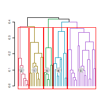

```r
LGs_upgma <- group_upgma(mark_no_dist, expected.groups = 5, inter = F)
plot(LGs_upgma)
```

You can define the expected number of groups in the `expected.groups` argument and check how the markers are split in the plotted dendrogram. Using argument `inter=TRUE` you can change interactively the number of groups defined by the red squares in the graphic.

## Genetic mapping of linkage group 3

Once marker assignment to linkage groups is finished, the mapping step can take place. First of all, you must set the mapping function that should be used to display the genetic map throughout the analysis. You can choose between `Kosambi` or `Haldane` mapping functions. To use Haldane, type:

```r
set_map_fun(type = "haldane")
```

To use Kosambi, type:

```r
set_map_fun(type = "kosambi")
```

If you do not set one of these functions, the kosambi is used as default.

Now, you must define which linkage group will be mapped. In other words, a linkage group must be `extracted` from the object of class `group` or `group.upgma`, in order to be mapped. For simplicity, we will start here with the smallest one, which is linkage group 3 (considering the `group` function). This can be easily done using the following code:

```r
LG3 <- make_seq(LGs, 3)
# or
# LG3 <- make_seq(LGs_upgma,3)
```

The first argument (`LGs`) is an object of class `group` or `group.upgma` and the second is a number indicating which linkage group will be extracted, according to the results stored in object `LGs`. The object `LG3`, generated by function `make_seq`, is of class `sequence`, showing that this function can be used with several types of objects.

If you type

```r
LG3
```

you will see which markers are comprised in the sequence, and also that no parameters have been estimated so far.

```
#>
#> Number of markers: 7
#> Markers in the sequence:
#> M7 M8 M13 M18 M22 SNP14 SNP16
#>
#> Parameters not estimated.
```

To order these markers, one can use a two-point based algorithm such as Seriation (Buetow and Chakravarti, 1987), Rapid Chain Delineation (Doerge, 1996), Recombination Counting and Ordering (Van Os et al., 2005) and Unidirectional Growth (Tan and Fu, 2006):

```r
(LG3_ser <- seriation(LG3, hmm = FALSE))
(LG3_rcd <- rcd(LG3, hmm = FALSE))
(LG3_rec <- record(LG3, hmm = FALSE))
(LG3_ug <- ug(LG3, hmm = FALSE))
```

Argument `hmm` defines if the function should run the HMM chain multipoint approach to estimate the genetic distances given the marker order provided by the two-points ordering algorithm. We set here the argument `hmm=FALSE` because we just want to obtain the marker order. We are not yet estimating the genetic distances. We suggest to use `hmm=TRUE` only when you already decided which order is the best because the HMM chain is the most computationally intensive step in the map building. You can use `rf_graph_table` to check the ordering quality (see details below) and make editions in the marker order using `drop_marker`. After, you can use `map` or `map_avoid_unlinked` functions to estimate the genetic distances (check session #Map-estimation-for-an-arbitrary-order).

Here we can check, there are some differences between each ordering algorithm results (results not shown).

Alternatively, you can also use the `mds_onemap` function to obtain a first draft for the order of the markers. The `mds_onemap` is a wrapper function that makes an interface between `OneMap` and `MDSMap` package. The ordering approach presented in `MDSMap` provides a faster and efficient way of ordering markers using multi-dimensional scaling. The method also provides diagnostics graphics and parameters to find outliers to help users to filter the dataset. You can find more information in `MDSMap` [vignette](https://CRAN.R-project.org/package=MDSMap). Here we will show a simple example of how it can be used for ordering our example markers from an outcrossing population.

```r
LG3_mds <- mds_onemap(LG3, hmm = FALSE)
```

```
#> Stress: 0.0735361952756395
#> Mean Nearest Neighbour Fit: 668.490762593474
```

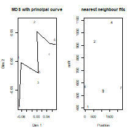

If you only specify the input sequence, mds_onemap will use the default parameters. It will also generate an MDSMap input file in the `out.file` file. You can use `out.file` in the MDSMap package to try other parameters too. The default method used is the principal curves, know more about using `?mds_onemap` and reading the MDSMap [vignette](https://CRAN.R-project.org/package=MDSMap).

Besides these algorithms use a two-point approach to order the markers, if you set `hmm=TRUE` a multipoint approach is applied to estimate the genetic distances after the order is estimated. Thus, it can happen that some markers are not considered linked when evaluated by multipoint information, and the function will return an error like this:

```
ERROR: The linkage between markers 1 and 2 did not reach the OneMap default criteria. They are probably segregating independently
```

You can automatically remove these markers setting argument `rm_unlinked = TRUE`. The marker will be removed, and the ordering algorithms will be restarted. Warning messages will inform which markers were removed. If you don’t get warning messages, it means that any marker needed to be removed. This is our case in this example, but if you obtain an error or warning running your dataset, you already know what happened.

**NOTE**: (new!) If your sequence has many markers (more than 60), we suggest to first use hmm=FALSE to check the ordering and after speed up `mds`, `seriation`, `rcd`, `record` and `ug` using BatchMap parallelization approach. See section `Speed up analysis with parallelization` for more information.

To order by comparing all possible orders (exhaustive search), the function `compare` can be used:

```r
LG3_comp <- compare(LG3)
```

**WARNING: This algorithm can take some time to run, depending on marker types in the linkage group. If you are working on a personal computer, without high capacity, we recommend using a maximum of ten markers.**

If you have more markers in your group, we suggest using the following explained approaches `order_seq`.

The first argument to the `compare` function is an object of class `sequence` (the extracted group `LG3`), and the object generated by this function is of class `compare`.

To see the results of the previous step, type:

```r
LG3_comp
```

```
#>
#> Number of orders: 50
#> Best 45 unique orders                         LOD    Nested LOD
#> --------------------------------------------------------------
#> order  1:    43  22   7  18   8  13  44
#>         CC  CC  CC  RR  RR  RR         0.00       0.00
#>         CC  CC  RC  RR  RR  RR        -1.48      -1.48
#> --------------------------------------------------------------
#> order  2:    43   7  22  18   8  13  44
#>         CC  CC  CC  RR  RR  RR        -0.05       0.00
#> --------------------------------------------------------------
#> order  3:    22  43   7  18   8  13  44
#>         CC  CC  CC  RR  RR  RR        -0.15       0.00
#>         CC  CC  RC  RR  RR  RR        -1.48      -1.33
#> --------------------------------------------------------------
#> order  4:    22   7  43  18   8  13  44
#>         CC  CC  CC  RR  RR  RR        -0.22       0.00
#> --------------------------------------------------------------
#> order  5:     7  43  22  18   8  13  44
#>         CC  CC  CC  RR  RR  RR        -0.25       0.00
#>         CC  CC  CR  RR  RR  RR        -2.26      -2.01
#> --------------------------------------------------------------
#> order  6:     7  22  43  18   8  13  44
#>         CC  CC  CC  RR  RR  RR        -0.42       0.00
#> --------------------------------------------------------------
#> order  7:     7  18   8  13  44  22  43
#>         CC  RR  RR  RR  RC  CC        -0.54       0.00
#> --------------------------------------------------------------
#> order  8:     7  44  13   8  18  22  43
#>         CR  RR  RR  RR  CC  CC        -0.65       0.00
#> --------------------------------------------------------------
#> order  9:     7  44  13   8  18  43  22
#>         CR  RR  RR  RR  CC  CC        -0.80       0.00
#> --------------------------------------------------------------
#> order 10:     7  18   8  13  44  43  22
#>         CC  RR  RR  RR  RC  CC        -0.87       0.00
#> --------------------------------------------------------------
#> order 11:    43  22   7  13  18   8  44
#>         CC  CC  CC  CC  RR  CC        -0.99       0.00
#> --------------------------------------------------------------
```

[output cut: 89 more lines]

```
#> order 41:     7  13  18   8  44  22  43
#>         CC  CC  RR  CC  RC  CC        -2.21       0.00
#> --------------------------------------------------------------
#> order 42:     7  22  43  13  44   8  18
#>         CC  CC  CC  RR  CC  RR        -2.29       0.00
#> --------------------------------------------------------------
#> order 43:     7  44   8  18  13  22  43
#>         CR  CC  RR  CC  CC  CC        -2.32       0.00
#> --------------------------------------------------------------
#> order 44:    43  22   7  44   8  13  18
#>         CC  CC  RR  CC  RR  CC        -2.32       0.00
#> --------------------------------------------------------------
#> order 45:    43   7  22  44   8  13  18
#>         CC  CC  RR  CC  RR  CC        -2.37       0.00
#> --------------------------------------------------------------
```

Remember that for outcrossing populations, one needs to estimate marker order and also linkage phases between markers for a given order. However, because two-point analysis provides information about linkage phases, this information is taken into consideration in the `compare` function, reducing the number of combinations to be evaluated. If a given linkage phase has LOD greater than 0.005 in the two-point analysis, we assume that this phase is very unlikely and so does not need to be evaluated in the multipoint procedure used by `compare`. We did extensive simulations, which showed that this is a good procedure.

By default, `OneMap` stores 50 orders, which may or may not be unique. The value of `LOD` refers to the overall LOD Score, considering all orders tested. `Nested LOD` refers to LOD Scores within a given order, that is, scores for different combinations of linkage phases for the same marker order.

Unless one has some biological information, it is a good idea to choose the order with the highest likelihood. The final map can then be obtained with the command.

```r
LG3_final <- make_seq(LG3_comp, 1, 1)
```

The first argument is the object of class `compare`. The second argument indicates which order is chosen: 1 is for the order with the highest likelihood, 2 is for the second-best, and so on. The third argument indicates which combination of phases is chosen for a given order: 1 also means the combination with the highest likelihood among all combinations of phases (based on Nested LOD).

For simplicity, these values are defaults, so typing

```r
LG3_final <- make_seq(LG3_comp)
```

have the same effect.

To see the final map, type:

```r
LG3_final
```

```
#>
#> Printing map:
#>
#> Markers           Position           Parent 1       Parent 2
#>
#> 43 SNP14              0.00           a |  | b       a |  | a
#> 22 M22               13.51           a |  | b       a |  | a
#>  7 M7                24.56           a |  | a       a |  | b
#> 18 M18               65.59           a |  | b       c |  | d
#>  8 M8                71.28           b |  | a       b |  | a
#> 13 M13               73.94           a |  | o       a |  | o
#> 44 SNP16             79.82           b |  | a       b |  | a
#>
#> 7 markers            log-likelihood: -398.6863
```

At the leftmost position, marker names are displayed. `Position` shows the cumulative distance using the Kosambi mapping function. Finally, `Parent 1` and `Parent 2` show the diplotypes of both parents, that is, the combination in which alleles are arranged in the chromosomes, given the estimated linkage phase. The notation is the same as that used by Wu et al. (2002a). Details about how ordering algorithms can be chosen and used are presented by Mollinari et al. (2009).

A careful examination of the results can be done using the function `rf_graph_table` to provide graphical view:

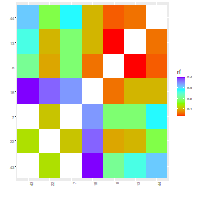

```r
rf_graph_table(LG3_final)
```

With the default arguments, this function plots the recombination fractions between the markers pointed in the axes. You can change the number of colors from the `rainbow` palette with the argument `n.colors`. Hot colors (more close to red) represent lower values of recombination fractions, as shown in the scale at the right side of the graphic. White cells indicate combinations of markers for which the recombination fractions cannot be estimated (D1 and D2). If you want to analyze the LOD values between the markers, use `graph.LOD = TRUE`.

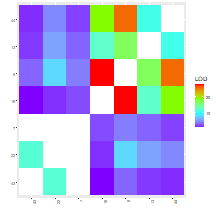

```r
rf_graph_table(LG3_final, graph.LOD = TRUE)
```

If you change the `inter` argument to `TRUE`, you should also specify an output HTML file name in `html.file`. This HTML contains an iterative plot graphic. If you hover the mouse cursor over the cells it shows some extra information about cells, as a percentage of missing data, marker name, and type. The output HTML file is generated in your work directory and opens automatically in your internet browser.

```r
rf_graph_table(LG3_final, inter = TRUE, mrk.axis= "names", html.file = "LG3.html")
```

For example, passing on the cell corresponding to markers `8` and `13`, you can see their names (`M8` and `M13` ), types (`B3.7` and `C.8`), recombination fraction (`rf = 0.03`) and LOD Scores for each possible linkage phase. This is quite useful in helping to interpret the results.

If you want to see corresponding marker numbers (not the names) in the axis, just change the argument `mrk.axis` to `numbers`. It can make the next steps easier.

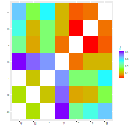

```r
rf_graph_table(LG3_final, inter = FALSE, mrk.axis = "numbers")
```

The `rf_graph_table` can also be used to check the order of markers based on the monotonicity of the matrix: as we get away from the secondary diagonal, the recombination fraction values should increase.

Changing other arguments of the function, you can add/remove labels of the axes (‘lab.xy’) and add a title to the graph (‘main’).

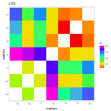

```r
rf_graph_table(LG3_final, main = "LG3", inter = FALSE, n.colors = 7, lab.xy = c("markers", "markers"))
```

## Genetic mapping of linkage group 2

Now, let us map the markers in linkage group number 2.

Again, `extract` that group from the object `LGs`:

```r
LG2 <- make_seq(LGs, 2)
LG2
```

```
#>
#> Number of markers: 17
#> Markers in the sequence:
#> M4 M9 M16 M20 M21 M23 M24 M27 M29 SNP17 SNP18 SNP20 SNP21 SNP22 SNP23 SNP24
#> SNP25
#>
#> Parameters not estimated.
```

Note that there are more than 10 markers in this group, so it is infeasible to use the `compare` function with all of them because it will take a very long time to proceed.

First, use `rcd` to get a preliminary order estimate:

```r
LG2_rcd <- rcd(LG2, hmm = F)
LG2_rcd
```

```
#>
#> Number of markers: 17
#> Markers in the sequence:
#> M27 SNP20 M16 M20 M4 M21 M23 SNP17 SNP18 M9 SNP21 SNP24 SNP23 M24 SNP22 SNP25
#> M29
#>
#> Parameters not estimated.
```

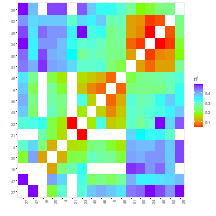

```r
rf_graph_table(LG2_rcd)
```

Use the `marker_type` function to check the segregation types of all markers in this group:

```r
marker_type(LG2)
```

```
#>  [1] "  Marker 4 ( M4 ) is of type A.4 \n"
#>  [2] "  Marker 9 ( M9 ) is of type D1.10 \n"
#>  [3] "  Marker 16 ( M16 ) is of type D2.17 \n"
#>  [4] "  Marker 20 ( M20 ) is of type A.1 \n"
#>  [5] "  Marker 21 ( M21 ) is of type D2.16 \n"
#>  [6] "  Marker 23 ( M23 ) is of type C.8 \n"
#>  [7] "  Marker 24 ( M24 ) is of type B3.7 \n"
#>  [8] "  Marker 27 ( M27 ) is of type D1.12 \n"
#>  [9] "  Marker 29 ( M29 ) is of type D1.13 \n"
#> [10] "  Marker 45 ( SNP17 ) is of type D1.10 \n"
#> [11] "  Marker 46 ( SNP18 ) is of type D1.10 \n"
#> [12] "  Marker 47 ( SNP20 ) is of type D1.10 \n"
#> [13] "  Marker 48 ( SNP21 ) is of type D1.10 \n"
#> [14] "  Marker 49 ( SNP22 ) is of type B3.7 \n"
#> [15] "  Marker 50 ( SNP23 ) is of type B3.7 \n"
#> [16] "  Marker 51 ( SNP24 ) is of type B3.7 \n"
#> [17] "  Marker 52 ( SNP25 ) is of type B3.7 \n"
```

Based on their segregation types and distribution on the preliminary map, markers `M4`, `M20`, `M24`, `SNP22`, `SNP23`, `SNP24` and `SNP25` are the most informative ones (type `A` is better, followed by type `B`). So, let us create a framework of ordered markers using `compare` for the most informative ones:

```r
LG2_init <- make_seq(twopts, c(4, 20, 24, 49,50,51, 52))
```

Here there is a automatic way of obtain a new sequence only with markers selected by type: (new!)

```r
LG2_init <- seq_by_type(sequence = LG2, mk_type = c("A", "B"))
marker_type(LG2_init)
```

```
#> [1] "  Marker 4 ( M4 ) is of type A.4 \n"
#> [2] "  Marker 20 ( M20 ) is of type A.1 \n"
#> [3] "  Marker 24 ( M24 ) is of type B3.7 \n"
#> [4] "  Marker 49 ( SNP22 ) is of type B3.7 \n"
#> [5] "  Marker 50 ( SNP23 ) is of type B3.7 \n"
#> [6] "  Marker 51 ( SNP24 ) is of type B3.7 \n"
#> [7] "  Marker 52 ( SNP25 ) is of type B3.7 \n"
```

```r
# If I want to reduce even more the number of markers
# I can use drop_marker function
LG2_init <- drop_marker(LG2_init, 52)
marker_type(LG2_init)
```

```
#> [1] "  Marker 4 ( M4 ) is of type A.4 \n"
#> [2] "  Marker 20 ( M20 ) is of type A.1 \n"
#> [3] "  Marker 24 ( M24 ) is of type B3.7 \n"
#> [4] "  Marker 49 ( SNP22 ) is of type B3.7 \n"
#> [5] "  Marker 50 ( SNP23 ) is of type B3.7 \n"
#> [6] "  Marker 51 ( SNP24 ) is of type B3.7 \n"
```

Now, the first argument to `make_seq` is an object of class `rf_2pts`, and the second argument is a vector of integers, specifying which molecular markers comprise the sequence.

```r
LG2_comp <- compare(LG2_init)
```

Select the best order:

```r
LG2_frame <- make_seq(LG2_comp)
```

Also, we can obtain a useful diagnostic graphic using the function `rf_graph_table`.

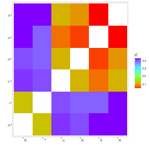

```r
rf_graph_table(LG2_frame, mrk.axis = "numbers")
```

The graphic shows that there are two groups of markers, once `M20` and `M4` are far from the other markers. These markers could be in other linkage groups, or they are distant in the same group. Adding more markers will give more information to solve this issue.

Next, let us try to map the remaining markers, one at a time. First, we will try to add the remaining most informative markers. Starting with `SNP25`:

```r
LG2_extend <- try_seq(LG2_frame, 52)
```

```r
LG2_extend
```

```
#>
#> LOD scores correspond to the best linkage phase combination
#> for each position
#>
#> The symbol "*" outside the box indicates that more than one
#> linkage phase is possible for the corresponding position
#>
#>
#>        Marker tested: 52
#>
#>        Markers     LOD
#>      =====================
#>      |                   |
#>      |           -26.44  |  1
#>      |  20               |
#>      |           -50.47  |  2
#>      |   4               |
#>      |            -8.34  |  3
#>      |  51               |
#>      |            -8.79  |  4
#>      |  50               |
#>      |            -8.43  |  5
#>      |  24               |
#>      |            -2.46  |  6
#>      |  49               |
#>      |             0.00  |  7
#>      |                   |
#>      =====================
```

Based on the LOD Scores, marker SNP25 is probably better located after `SNP22` (number 49). Detailed results can be seen with:

```r
print(LG2_extend, 7)
```

```
#>
#> LOD is the overall LOD score (among all orders)
#>
#> NEST.LOD is the LOD score within the order
#>
#> Marker tested: 52
#> --------------
#> |     |      |
#> | 20  |      |
#> |     |  CR  |
#> |  4  |      |
#> |     |  CC  |
#> | 51  |      |
#> |     |  CC  |
#> | 50  |      |
#> |     |  CC  |
#> | 24  |      |
#> |     |  CC  |
#> | 49  |      |
#> |     |  CC  |
#> | 52  |      |
#> |     |      |
#> |------------|
#> | LOD |   0.0|
#> |------------|
#> |NEST.|      |
#> | LOD |   0.0|
#> --------------
```

The second argument indicates the position where to place the marker. Note that the first allele arrangement is the most likely one.

It should be pointed out that the framework created by the function `compare` (with `M20`, `M4`, `SNP24`, `SNP23`, `M24` and `SNP22`, or numbers `20`, `4`, `51`,`50`, `24` and `49`) could be in reverse order (`SNP22`, `M24`, `SNP23`, `SNP24`, `M4` and `M20`, or numbers `49`, `24`, `50`, `51`, `4`, `20`) and still represent the same map. Thus, the positioning of markers with the `try_seq` command can be different on your computer. For example, here marker `SNP25` (number `52`) was better placed at position 7; however, if you obtain a reversed order, marker `SNP25` would be better placed in position 1. In both cases, the best position for this marker is after `SNP22`.